# ZeppR

**ZeppR** is an R/Shiny desktop app for data analysis of Zepp body data. The data used for this can be retreived from the Zepp App via Download of a `csv` file. A requirement for a full dataset usable with this application is the use of an amazfit digital body scale.

## Demo

You can **[watch the demo here on YouTube](https://youtu.be/Q_qFe8FBdOw)** or click the thumbnail below:

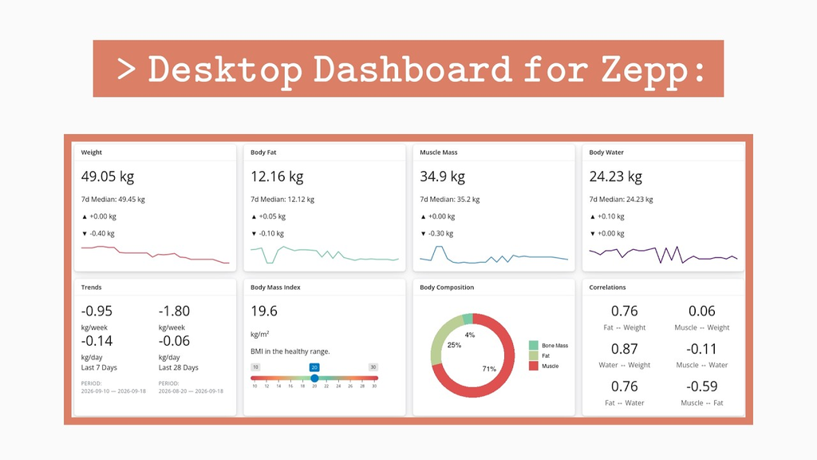

## Features

- Import Zepp “BODY” dataset `csv`-file
- Data cleaning:
  - remove incomplete measurements
  - remove non-user measurements (e.g. from other family members accidentally associated with the user’s account)
- Interactive date-range selection
- Body-composition overview, median analysis and trends for core data:
  - body mass
  - body fat
  - muscle mass
  - water mass
- BMI analysis
- Table view (searchable):
  - Cleaned data
  - raw-data
- Plots (date-range sensitive):
  - Visualizations of core metrics (weight, fat, muscle, water)
  - Correlation graphs

## Project Structure

```
zeppR/
├── app.R
├── composition_calculations.R
├── data/
│   └── user00/ # sample user data for testing
├── server/
│   ├── server.R
│   ├── dashboard_content.R
│   └── plots.R
├── ui/
│   ├── ui.R
│   ├── dashboard.R
│   └── mydata.R
├── HOWTO.Rmd # Zepp data retrieval - Tutorial
├── README.md # github info file
└── zeppR.Rproj
```

Development files, backups, videos, design material, and non-public data are kept outside the repository through `.gitignore`.

## Data

The repository contains only the `user00` sample dataset used for development and demonstration.

Personal body-composition data and other development data are excluded from version control.

## Running the App

Clone the repository and open `zeppR.Rproj` in RStudio.

Then run:

```r
shiny::runApp()
```

## Dependencies

- `r-base` (backend, plots)
- `shiny` (interactive browser frontend)
- `bslib` (theme)
- `DT` (interactive data tables)
- `ggplot2` (dashboard plots)
- R Markdown (documentation)

## Zepp Data Retrieval

For more information on how to download your personal data from Zepp, check out `HOWTO.Rmd`.

## Add a launcher (Linux only)

### Primitive launcher

For this to work you need a functioning r-base and the packages required for this app (see *dependencies*) installed on your system. By creating a launcher, you can start the app without starting Rstudio or entering the terminal and run the respective commands.

To add a launcher, e.g. to a pane, create an empty launcher that leads to the file `zeppR.sh` in the apps root directory containing the following command:

```bash
#!/bin/bash
R -e "shiny::runApp('.', launch.browser = TRUE)"
```

In the launcher settings, set the working directory to the app’s root dir and the command to `./zeppR.sh`.

Don’t forget to make `zeppR.sh` executable using e.g.

```bash
sudo chmod +x zeppR.sh
```

If desired, you can use the icon from the root directory via the image selection option of your launcher menu to customize the button.

This process needs to be terminated manually, e.g. using `pkill`.

### Tab-exit-terminated process

For a more convenient process management, use the script provided in the code’s root directory.

## Status

This project is under active development.

## License

ZeppR is free and open-source software released under the **GNU General Public License (GPL)**.

There is only one additional requirement:

> **Please pet a kitty. 🐈**

This requirement is, of course, strictly enforced by absolutely no one.